# Analyzing Ford GoBike System Data

## Preliminary Wrangling

This document explores a dataset includes information about approximately 1,860,000 bike ride made in a bike-sharing system **(Ford GoBike)**, covering the greater San Francisco Bay area.

```python
# import all packages and set plots to be embedded inline
import numpy as np
import pandas as pd
import matplotlib.pyplot as plt
import matplotlib.ticker as tick
import seaborn as sb

from requests import get
from io import BytesIO
from zipfile import ZipFile
import datetime

import glob
import os

%matplotlib inline
```

```python
folder_name_of_csvs = 'fordgobike-data'
os.makedirs(folder_name_of_csvs)
os.makedirs('Figures')

colors = ['#E7583F', '#F6BB43', '#44C09D', '#d1d1d1']
```

## Gathering

```python
# Download and un-zip data files

for month in range(1,13):
    month_string = str(month)
    month_leading_zero = month_string.zfill(2)

    bike_data_url = 'https://s3.amazonaws.com/fordgobike-data/2018' + month_leading_zero + '-fordgobike-tripdata.csv.zip'
    response = get(bike_data_url)

    # Open zip file, then put extracted zip file into the folder
    unzipped_file = ZipFile(BytesIO(response.content))
    unzipped_file.extractall(folder_name_of_csvs)
```

```python
# Merge data files into one DataFrame, then export it as a 'csv' file.

all_files = glob.glob(os.path.join(folder_name_of_csvs, "*.csv"))
df = pd.concat((pd.read_csv(f) for f in all_files), ignore_index = True, sort = False)
df.to_csv('master_data.csv', index=False)
```

```python
df = pd.read_csv('master_data.csv')
```

## Assessing

```python
df.sample(10)
```

|  | duration_sec | start_time | end_time | start_station_id | start_station_name | start_station_latitude | start_station_longitude | end_station_id | end_station_name | end_station_latitude | end_station_longitude | bike_id | user_type | member_birth_year | member_gender | bike_share_for_all_trip |
| --- | --- | --- | --- | --- | --- | --- | --- | --- | --- | --- | --- | --- | --- | --- | --- | --- |
| 378124 | 81 | 2018-04-17 17:00:33.1650 | 2018-04-17 17:01:54.6890 | 321.0 | 5th at Folsom | 37.780146 | -122.403071 | 321.0 | 5th at Folsom | 37.780146 | -122.403071 | 2525 | Subscriber | 1984.0 | Female | No |
| 278911 | 699 | 2018-03-10 17:44:43.1490 | 2018-03-10 17:56:22.9110 | 84.0 | Duboce Park | 37.769200 | -122.433812 | 127.0 | Valencia St at 21st St | 37.756708 | -122.421025 | 101 | Customer | 1986.0 | Female | No |
| 1396792 | 2186 | 2018-10-31 23:14:31.0210 | 2018-10-31 23:50:57.0500 | 370.0 | Jones St at Post St | 37.787327 | -122.413278 | 284.0 | Yerba Buena Center for the Arts (Howard St at ... | 37.784872 | -122.400876 | 2873 | Subscriber | 1991.0 | Male | No |
| 143592 | 247 | 2018-02-14 18:08:39.5770 | 2018-02-14 18:12:46.8820 | 24.0 | Spear St at Folsom St | 37.789677 | -122.390428 | 16.0 | Steuart St at Market St | 37.794130 | -122.394430 | 983 | Subscriber | 1973.0 | Male | No |
| 1495629 | 303 | 2018-10-16 16:29:32.2060 | 2018-10-16 16:34:36.0110 | 6.0 | The Embarcadero at Sansome St | 37.804770 | -122.403234 | 15.0 | San Francisco Ferry Building (Harry Bridges Pl... | 37.795392 | -122.394203 | 277 | Subscriber | 1963.0 | Female | No |
| 1226780 | 768 | 2018-09-27 21:12:13.1900 | 2018-09-27 21:25:01.3700 | 280.0 | 6th St at San Fernando St (Temporary Location) | 37.337038 | -121.884125 | 296.0 | 5th St at Virginia St | 37.325998 | -121.877120 | 2586 | Subscriber | 1996.0 | Male | Yes |
| 480643 | 1149 | 2018-05-25 09:01:07.0010 | 2018-05-25 09:20:16.9860 | 285.0 | Webster St at O'Farrell St | 37.783521 | -122.431158 | 81.0 | Berry St at 4th St | 37.775880 | -122.393170 | 2530 | Subscriber | 1994.0 | Male | No |
| 1241771 | 861 | 2018-09-26 07:15:12.4640 | 2018-09-26 07:29:34.2240 | 133.0 | Valencia St at 22nd St | 37.755213 | -122.420975 | 41.0 | Golden Gate Ave at Polk St | 37.781270 | -122.418740 | 131 | Subscriber | 1986.0 | Male | No |
| 1658109 | 645 | 2018-11-14 06:54:49.5560 | 2018-11-14 07:05:34.9680 | 92.0 | Mission Bay Kids Park | 37.772301 | -122.393028 | 16.0 | Steuart St at Market St | 37.794130 | -122.394430 | 1808 | Subscriber | 1982.0 | Male | No |
| 1486216 | 492 | 2018-10-17 18:21:09.0490 | 2018-10-17 18:29:21.4840 | 23.0 | The Embarcadero at Steuart St | 37.791464 | -122.391034 | 30.0 | San Francisco Caltrain (Townsend St at 4th St) | 37.776598 | -122.395282 | 2152 | Subscriber | 1982.0 | Male | No |

```python
df.head()
```

|  | duration_sec | start_time | end_time | start_station_id | start_station_name | start_station_latitude | start_station_longitude | end_station_id | end_station_name | end_station_latitude | end_station_longitude | bike_id | user_type | member_birth_year | member_gender | bike_share_for_all_trip |
| --- | --- | --- | --- | --- | --- | --- | --- | --- | --- | --- | --- | --- | --- | --- | --- | --- |
| 0 | 75284 | 2018-01-31 22:52:35.2390 | 2018-02-01 19:47:19.8240 | 120.0 | Mission Dolores Park | 37.761420 | -122.426435 | 285.0 | Webster St at O'Farrell St | 37.783521 | -122.431158 | 2765 | Subscriber | 1986.0 | Male | No |
| 1 | 85422 | 2018-01-31 16:13:34.3510 | 2018-02-01 15:57:17.3100 | 15.0 | San Francisco Ferry Building (Harry Bridges Pl... | 37.795392 | -122.394203 | 15.0 | San Francisco Ferry Building (Harry Bridges Pl... | 37.795392 | -122.394203 | 2815 | Customer | NaN | NaN | No |
| 2 | 71576 | 2018-01-31 14:23:55.8890 | 2018-02-01 10:16:52.1160 | 304.0 | Jackson St at 5th St | 37.348759 | -121.894798 | 296.0 | 5th St at Virginia St | 37.325998 | -121.877120 | 3039 | Customer | 1996.0 | Male | No |
| 3 | 61076 | 2018-01-31 14:53:23.5620 | 2018-02-01 07:51:20.5000 | 75.0 | Market St at Franklin St | 37.773793 | -122.421239 | 47.0 | 4th St at Harrison St | 37.780955 | -122.399749 | 321 | Customer | NaN | NaN | No |
| 4 | 39966 | 2018-01-31 19:52:24.6670 | 2018-02-01 06:58:31.0530 | 74.0 | Laguna St at Hayes St | 37.776435 | -122.426244 | 19.0 | Post St at Kearny St | 37.788975 | -122.403452 | 617 | Subscriber | 1991.0 | Male | No |

```python
df.info(null_counts=True)
```

```
<class 'pandas.core.frame.DataFrame'>
RangeIndex: 1863721 entries, 0 to 1863720
Data columns (total 16 columns):
duration_sec               1863721 non-null int64
start_time                 1863721 non-null object
end_time                   1863721 non-null object
start_station_id           1851950 non-null float64
start_station_name         1851950 non-null object
start_station_latitude     1863721 non-null float64
start_station_longitude    1863721 non-null float64
end_station_id             1851950 non-null float64
end_station_name           1851950 non-null object
end_station_latitude       1863721 non-null float64
end_station_longitude      1863721 non-null float64
bike_id                    1863721 non-null int64
user_type                  1863721 non-null object
member_birth_year          1753003 non-null float64
member_gender              1753354 non-null object
bike_share_for_all_trip    1863721 non-null object
dtypes: float64(7), int64(2), object(7)
memory usage: 227.5+ MB
```

```python
df.describe()
```

|  | duration_sec | start_station_id | start_station_latitude | start_station_longitude | end_station_id | end_station_latitude | end_station_longitude | bike_id | member_birth_year |
| --- | --- | --- | --- | --- | --- | --- | --- | --- | --- |
| count | 1.863721e+06 | 1.851950e+06 | 1.863721e+06 | 1.863721e+06 | 1.851950e+06 | 1.863721e+06 | 1.863721e+06 | 1.863721e+06 | 1.753003e+06 |
| mean | 8.573026e+02 | 1.196744e+02 | 3.776678e+01 | -1.223492e+02 | 1.181730e+02 | 3.776690e+01 | -1.223487e+02 | 2.296851e+03 | 1.983088e+03 |
| std | 2.370379e+03 | 1.003976e+02 | 1.057689e-01 | 1.654634e-01 | 1.004403e+02 | 1.056483e-01 | 1.650597e-01 | 1.287733e+03 | 1.044289e+01 |
| min | 6.100000e+01 | 3.000000e+00 | 3.726331e+01 | -1.224737e+02 | 3.000000e+00 | 3.726331e+01 | -1.224737e+02 | 1.100000e+01 | 1.881000e+03 |
| 25% | 3.500000e+02 | 3.300000e+01 | 3.777106e+01 | -1.224114e+02 | 3.000000e+01 | 3.777106e+01 | -1.224094e+02 | 1.225000e+03 | 1.978000e+03 |
| 50% | 5.560000e+02 | 8.900000e+01 | 3.778107e+01 | -1.223974e+02 | 8.800000e+01 | 3.778127e+01 | -1.223971e+02 | 2.338000e+03 | 1.985000e+03 |
| 75% | 8.720000e+02 | 1.860000e+02 | 3.779625e+01 | -1.222865e+02 | 1.830000e+02 | 3.779728e+01 | -1.222894e+02 | 3.333000e+03 | 1.991000e+03 |
| max | 8.636600e+04 | 3.810000e+02 | 4.551000e+01 | -7.357000e+01 | 3.810000e+02 | 4.551000e+01 | -7.357000e+01 | 6.234000e+03 | 2.000000e+03 |

```python
df.duplicated().sum()
```

```
0
```

```python
len(df[df.member_birth_year < 1900])
```

```
31
```

### Issues:

- Type issues:
  - *start_time* and *end_time* are objects instead of datetimes.
  - *bike_id*, *start_station_id* and *end_station_id* preferred to be strings, since we won't perform any calculations on them.
  - *user_type*, *member_gender* and *bike_share_for_all_trip* are objects instead of categories.
- Add new useful columns:
  - Age of the member, *'member_age'.*
  - Starting month, *'start_month'.*
  - Starting day, *'start_day'.*
  - Starting hour, *'start_hour'.*
- Fix outliers in *'member_age'* and those who were born before 1900.
- Drop columns that we do not benefit from them (Doesn't give enough insights).

## Cleaning

```python
df_clean = df.copy()
```

**Define**

Change data type to appropriate types

**Code**

```python
df_clean.bike_id = df_clean.bike_id.astype(str)
df_clean.start_station_id = df_clean.bike_id.astype(str)
df_clean.end_station_id = df_clean.bike_id.astype(str)

df_clean.start_time = pd.to_datetime(df_clean.start_time)
df_clean.end_time = pd.to_datetime(df_clean.end_time)

df_clean.user_type = df_clean.user_type.astype('category')
df_clean.member_gender = df_clean.member_gender.astype('category')
df_clean.bike_share_for_all_trip = df_clean.bike_share_for_all_trip.astype('category')
```

**Test**

```python
df_clean.info()
```

```
<class 'pandas.core.frame.DataFrame'>
RangeIndex: 1863721 entries, 0 to 1863720
Data columns (total 16 columns):
duration_sec               int64
start_time                 datetime64[ns]
end_time                   datetime64[ns]
start_station_id           object
start_station_name         object
start_station_latitude     float64
start_station_longitude    float64
end_station_id             object
end_station_name           object
end_station_latitude       float64
end_station_longitude      float64
bike_id                    object
user_type                  category
member_birth_year          float64
member_gender              category
bike_share_for_all_trip    category
dtypes: category(3), datetime64[ns](2), float64(5), int64(1), object(5)
memory usage: 190.2+ MB
```

**Define**

Add new useful columns from 'start_time' column

**Code**

```python
df_clean['start_month'] = df_clean['start_time'].dt.month.astype(int)
df_clean['start_day'] = df_clean['start_time'].dt.strftime('%a')
df_clean['start_hour'] = df_clean['start_time'].dt.hour
```

**Test**

```python
df_clean.head()
```

|  | duration_sec | start_time | end_time | start_station_id | start_station_name | start_station_latitude | start_station_longitude | end_station_id | end_station_name | end_station_latitude | end_station_longitude | bike_id | user_type | member_birth_year | member_gender | bike_share_for_all_trip | start_month | start_day | start_hour |
| --- | --- | --- | --- | --- | --- | --- | --- | --- | --- | --- | --- | --- | --- | --- | --- | --- | --- | --- | --- |
| 0 | 75284 | 2018-01-31 22:52:35.239 | 2018-02-01 19:47:19.824 | 2765 | Mission Dolores Park | 37.761420 | -122.426435 | 2765 | Webster St at O'Farrell St | 37.783521 | -122.431158 | 2765 | Subscriber | 1986.0 | Male | No | 1 | Wed | 22 |
| 1 | 85422 | 2018-01-31 16:13:34.351 | 2018-02-01 15:57:17.310 | 2815 | San Francisco Ferry Building (Harry Bridges Pl... | 37.795392 | -122.394203 | 2815 | San Francisco Ferry Building (Harry Bridges Pl... | 37.795392 | -122.394203 | 2815 | Customer | NaN | NaN | No | 1 | Wed | 16 |
| 2 | 71576 | 2018-01-31 14:23:55.889 | 2018-02-01 10:16:52.116 | 3039 | Jackson St at 5th St | 37.348759 | -121.894798 | 3039 | 5th St at Virginia St | 37.325998 | -121.877120 | 3039 | Customer | 1996.0 | Male | No | 1 | Wed | 14 |
| 3 | 61076 | 2018-01-31 14:53:23.562 | 2018-02-01 07:51:20.500 | 321 | Market St at Franklin St | 37.773793 | -122.421239 | 321 | 4th St at Harrison St | 37.780955 | -122.399749 | 321 | Customer | NaN | NaN | No | 1 | Wed | 14 |
| 4 | 39966 | 2018-01-31 19:52:24.667 | 2018-02-01 06:58:31.053 | 617 | Laguna St at Hayes St | 37.776435 | -122.426244 | 617 | Post St at Kearny St | 37.788975 | -122.403452 | 617 | Subscriber | 1991.0 | Male | No | 1 | Wed | 19 |

**Define**

Calculate the members ages

**Code**

```python
df_clean['member_age'] = 2019-df_clean['member_birth_year']
```

**Test**

```python
df_clean.head()
```

|  | duration_sec | start_time | end_time | start_station_id | start_station_name | start_station_latitude | start_station_longitude | end_station_id | end_station_name | end_station_latitude | end_station_longitude | bike_id | user_type | member_birth_year | member_gender | bike_share_for_all_trip | start_month | start_day | start_hour | member_age |
| --- | --- | --- | --- | --- | --- | --- | --- | --- | --- | --- | --- | --- | --- | --- | --- | --- | --- | --- | --- | --- |
| 0 | 75284 | 2018-01-31 22:52:35.239 | 2018-02-01 19:47:19.824 | 2765 | Mission Dolores Park | 37.761420 | -122.426435 | 2765 | Webster St at O'Farrell St | 37.783521 | -122.431158 | 2765 | Subscriber | 1986.0 | Male | No | 1 | Wed | 22 | 33.0 |
| 1 | 85422 | 2018-01-31 16:13:34.351 | 2018-02-01 15:57:17.310 | 2815 | San Francisco Ferry Building (Harry Bridges Pl... | 37.795392 | -122.394203 | 2815 | San Francisco Ferry Building (Harry Bridges Pl... | 37.795392 | -122.394203 | 2815 | Customer | NaN | NaN | No | 1 | Wed | 16 | NaN |
| 2 | 71576 | 2018-01-31 14:23:55.889 | 2018-02-01 10:16:52.116 | 3039 | Jackson St at 5th St | 37.348759 | -121.894798 | 3039 | 5th St at Virginia St | 37.325998 | -121.877120 | 3039 | Customer | 1996.0 | Male | No | 1 | Wed | 14 | 23.0 |
| 3 | 61076 | 2018-01-31 14:53:23.562 | 2018-02-01 07:51:20.500 | 321 | Market St at Franklin St | 37.773793 | -122.421239 | 321 | 4th St at Harrison St | 37.780955 | -122.399749 | 321 | Customer | NaN | NaN | No | 1 | Wed | 14 | NaN |
| 4 | 39966 | 2018-01-31 19:52:24.667 | 2018-02-01 06:58:31.053 | 617 | Laguna St at Hayes St | 37.776435 | -122.426244 | 617 | Post St at Kearny St | 37.788975 | -122.403452 | 617 | Subscriber | 1991.0 | Male | No | 1 | Wed | 19 | 28.0 |

**Define**

Fix outliers in 'member_age' and those who were born before 1900

**Code**

```
count    1.753003e+06
mean     3.591204e+01
std      1.044289e+01
min      1.900000e+01
50%      3.400000e+01
98%      6.200000e+01
max      1.380000e+02
Name: member_age, dtype: float64
```

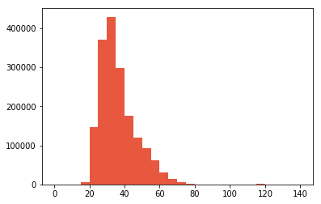

```python
age_bins = np.arange( 0, df_clean.member_age.max()+5, 5)
plt.hist( data = df_clean, x = 'member_age', bins = age_bins, color = colors[0]);
df_clean.member_age.describe(percentiles = [.98])
```

**As 98% of members are below 63 years old, we will keep only members below 65 year old.**

```python
df_clean = df_clean.query('member_age <=65')

# Set appropriate data type
df_clean.member_age = df_clean.member_age.astype(int)
df_clean.member_birth_year = df_clean.member_birth_year.astype(int)
```

**Test**

```python
df_clean.describe()
```

|  | duration_sec | start_station_latitude | start_station_longitude | end_station_latitude | end_station_longitude | member_birth_year | start_month | start_hour | member_age |
| --- | --- | --- | --- | --- | --- | --- | --- | --- | --- |
| count | 1.734546e+06 | 1.734546e+06 | 1.734546e+06 | 1.734546e+06 | 1.734546e+06 | 1.734546e+06 | 1.734546e+06 | 1.734546e+06 | 1.734546e+06 |
| mean | 7.777904e+02 | 3.776621e+01 | -1.223482e+02 | 3.776631e+01 | -1.223476e+02 | 1.983491e+03 | 6.978487e+00 | 1.350210e+01 | 3.550860e+01 |
| std | 1.986498e+03 | 1.069935e-01 | 1.690171e-01 | 1.068618e-01 | 1.685942e-01 | 9.650400e+00 | 3.114264e+00 | 4.765848e+00 | 9.650400e+00 |
| min | 6.100000e+01 | 3.726331e+01 | -1.224737e+02 | 3.726331e+01 | -1.224737e+02 | 1.954000e+03 | 1.000000e+00 | 0.000000e+00 | 1.900000e+01 |
| 25% | 3.450000e+02 | 3.777041e+01 | -1.224114e+02 | 3.777106e+01 | -1.224094e+02 | 1.978000e+03 | 5.000000e+00 | 9.000000e+00 | 2.800000e+01 |
| 50% | 5.430000e+02 | 3.778107e+01 | -1.223971e+02 | 3.778107e+01 | -1.223959e+02 | 1.986000e+03 | 7.000000e+00 | 1.400000e+01 | 3.300000e+01 |
| 75% | 8.410000e+02 | 3.779581e+01 | -1.222831e+02 | 3.779625e+01 | -1.222876e+02 | 1.991000e+03 | 1.000000e+01 | 1.700000e+01 | 4.100000e+01 |
| max | 8.628100e+04 | 4.551000e+01 | -7.357000e+01 | 4.551000e+01 | -7.357000e+01 | 2.000000e+03 | 1.200000e+01 | 2.300000e+01 | 6.500000e+01 |

**Define**

Drop columns that we do not benefit from them (Doesn't give enough insights).

**Code**

```python
df_clean = df_clean.drop('start_time', 1)
df_clean = df_clean.drop('member_birth_year', 1)

df_clean = df_clean.drop('end_time', 1)
df_clean = df_clean.drop('start_station_id', 1)
df_clean = df_clean.drop('start_station_latitude', 1)
df_clean = df_clean.drop('start_station_longitude', 1)
df_clean = df_clean.drop('end_station_id', 1)
df_clean = df_clean.drop('end_station_latitude', 1)
df_clean = df_clean.drop('end_station_longitude', 1)
#df_clean = df_clean.drop('bike_id', 1)

df_clean = df_clean.drop('bike_share_for_all_trip', 1)
```

**Test**

```python
list(df_clean)
```

```
['duration_sec',
 'start_station_name',
 'end_station_name',
 'bike_id',
 'user_type',
 'member_gender',
 'start_month',
 'start_day',
 'start_hour',
 'member_age']
```

## Store

```python
df_clean.to_csv('cleaned_master_data.csv', index = False)
```

```python
df_clean = pd.read_csv('cleaned_master_data.csv')
```

### What is the structure of your dataset?

There were around 1,860,000 bike rides in the dataset that was in 2018 at the greater San Francisco Bay area. The dataset contained features about the trip, bike, station and the member. Most variables in the dataset are numeric.

The dataset was further enhanced with features that I may find neccessary to perform interesting analysis: A few features (*start_month, start_day, start_hour, member_age*) were added by me due to their usefulness.

### What is/are the main feature(s) of interest in your dataset?

I am interested in finding the relation between age and using a bike. Also, I am curious to know wether subscribers use the bikes more than regular customers.

### What features in the dataset do you think will help support your investigation into your feature(s) of interest?

I expect that the starting day will have the strongest effect on the bikes usage. Also, the hour will have a significant effect.

## Univariate Exploration

I will start by looking at how does time (month, day or hour) effects the number of bikes rented. Then, I will explore the genders.

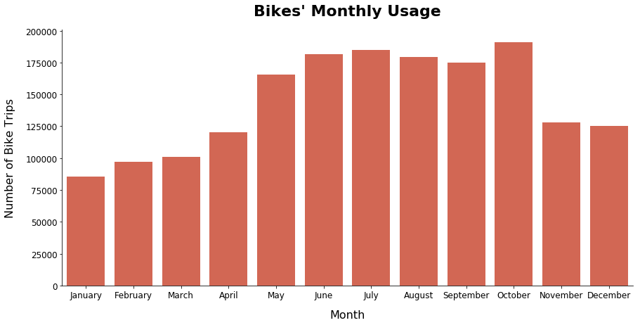

```python
months_ticks = ['January', 'February', 'March', 'April', 'May', 'June', 'July', 'August',
                'September', 'October', 'November', 'December'];

fig = sb.catplot( data = df_clean, x = 'start_month', kind = 'count', color = colors[0])
plt.xlabel('Month', labelpad = 14,fontsize = 16)
plt.ylabel('Number of Bike Trips', labelpad = 14,fontsize = 16)
plt.title('Bikes\' Monthly Usage', y = 1, fontsize = 22, fontweight='semibold', pad = 20);
fig.set_xticklabels(months_ticks)

plt.tick_params(axis='x', labelsize=12)
plt.tick_params(axis='y', labelsize=12)

plt.gcf().set_size_inches(14,6)
plt.figsize=(13,6)

plt.savefig('Figures/bikes_monthly_usage.png', bbox_inches = 'tight', pad_inches = 1)
```

The demand is high in the summer months, probably due to tourism. In contrast, winter months are the worst, probably due to the bad weather conditions. Clearly, 2 factors effect the demand, weather and work. That is why the peak is in October, as it is in the summer session and there is work at that time.

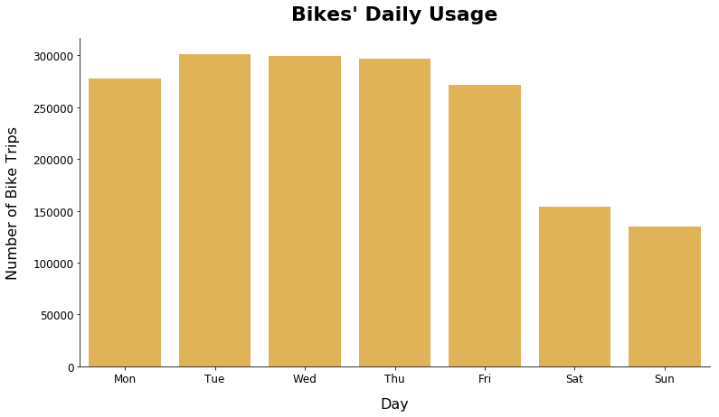

```python
days_ticks = ['Mon', 'Tue', 'Wed', 'Thu', 'Fri', 'Sat', 'Sun'];

fig = sb.catplot( data = df_clean, x = 'start_day', kind = 'count', color = colors[1], order = days_ticks)
plt.xlabel('Day', labelpad = 14, fontsize = 16)
plt.ylabel('Number of Bike Trips', labelpad = 14, fontsize = 16)
plt.title('Bikes\' Daily Usage', y = 1, fontsize = 22, fontweight='semibold', pad = 20);

plt.tick_params(axis='x', labelsize=12)
plt.tick_params(axis='y', labelsize=12)

plt.gcf().set_size_inches(12,6)
plt.figsize=(10,6)

plt.savefig('Figures/bikes_daily_usage.png', bbox_inches = 'tight', pad_inches = 1)
```

As the highest usage of the bikes is in weekdays, it is probably used to commute to work.

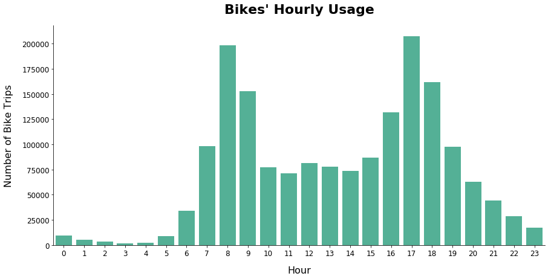

```python
fig = sb.catplot( data = df_clean, x = 'start_hour', kind = 'count', color = colors[2])
plt.xlabel('Hour', labelpad = 14, fontsize = 16)
plt.ylabel('Number of Bike Trips', labelpad = 14, fontsize = 16)
plt.title('Bikes\' Hourly Usage', y = 1, fontsize = 22, fontweight='semibold', pad = 20);

plt.tick_params(axis='x', labelsize=12)
plt.tick_params(axis='y', labelsize=12)

plt.gcf().set_size_inches(14,6)
plt.figsize=(13,6)

plt.savefig('Figures/bikes_hourly_usage.png', bbox_inches = 'tight', pad_inches = 1)
```

As the peaks are at (8 AM - 9 AM) and (4 PM - 6 PM), this suggests that the bikes are probably used to commute to work, since these are the times when people get to and gat back from work.

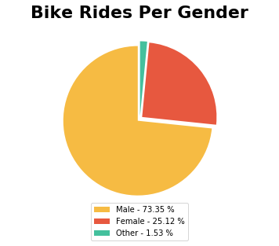

```python
x = np.char.array(['Male', 'Female', 'Other'])
y = np.array(list(df_clean[df_clean['member_gender'] != 'None']['member_gender'].value_counts())[0:3])

porcent = 100.*y/y.sum()
explode = (0.5, 0.5, 0.5)

patches, texts = plt.pie(y, startangle=90, radius = 13, explode = explode, colors = [colors[1], colors[0], colors[2]]);
labels = ['{0} - {1:1.2f} %'.format(i,j) for i,j in zip(x, porcent)]

plt.legend(patches, labels, loc='center right', bbox_to_anchor=(0.7, -0.1), fontsize = 10)
plt.axis('equal');
plt.title('Bike Rides Per Gender',   y = 1, fontsize = 22, fontweight='semibold', pad = 20)

plt.savefig('Figures/bike_rides_per_gender.png', bbox_inches = 'tight', pad_inches = 1)
```

Males rides are approximately 3 times more than females rides count.

### Discuss the distribution(s) of your variable(s) of interest. Were there any unusual points? Did you need to perform any transformations?

No unusual points was observed. There were some intersting findings about the variables:

- People use this service on weekdays more than weekends.
- The peak hours are 8 AM and 5 PM.
- It is clear that the bikes are used for work commute.
- Male took around %73 of all bike rides, and female took around %25 of them.

### Of the features you investigated, were there any unusual distributions? Did you perform any operations on the data to tidy, adjust, or change the form of the data? If so, why did you do this?

- I have inserted new columns in order to perform calculations and draw visualizations easly.
- As 98% of members are 18 to 63 years old amd there are many outliers, I cleaned the data by removing rows that contains member ages more than 65 years old. Also, there were members with more than 100 years old.

## Bivariate Exploration

Here, I will explore the dataset more by considering the customer type and trip duration.

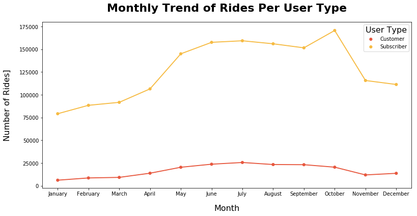

```python
user_type_count_per_year_df = df_clean.groupby(["start_month", "user_type"]).size().reset_index()

plt.figure(figsize=(13,6))
ax = sb.pointplot(x='start_month', y=0, hue='user_type', palette = colors, scale=.7, data=user_type_count_per_year_df)
plt.title('Monthly Trend of Rides Per User Type', y = 1, fontsize = 22, fontweight='semibold', pad = 20)
plt.xlabel('Month', labelpad=16, fontsize = 16)
plt.ylabel('Number of Rides]', labelpad=16, fontsize = 16)
leg = ax.legend()
leg.set_title('User Type',prop={'size':16})
ax = plt.gca()
ax.set_xticklabels(months_ticks)

plt.savefig('Figures/monthly_trend_ride_per_type.png', bbox_inches = 'tight', pad_inches = 1)
```

- Subscribers: The highest demand is from May to October, reaching the peak in October. Subscribers are probably regular riders using bikes as daily transportation.
- Customers: The demand is high around summer session, reaching the peak in July. Customers are probably tourists coming to visit the Bay Area.

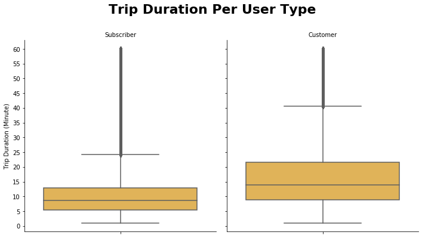

```python
data2 = df_clean.query('duration_sec < 3600')
data2['duration_min'] = data2['duration_sec'] / 60

fig = sb.catplot(data=data2, y='duration_min', col="user_type", kind='box', color = colors[1]);
fig.set_titles(col_template = '{col_name}')
fig.set_axis_labels("", "Trip Duration (Minute)")
fig.fig.suptitle('Trip Duration Per User Type', y = 1.1, fontsize=22, fontweight='semibold');

plt.yticks( np.arange(0, 60+5, 5));

plt.savefig('Figures/trip_duration_per_type.png', bbox_inches = 'tight', pad_inches = 1)
```

### Talk about some of the relationships you observed in this part of the investigation. How did the feature(s) of interest vary with other features in the dataset?

There are intersting findings when I consider the user type in the analysis. As suggested above, subscribers are mainly daily commuters who use the bike to go to work. Subscribers trips are often less than 20 minutes, as they usually use it to go to work only. However, subscribers still use the bikes on the summer vacation and arount it (May to Oct). On the other hand, customers are most probably tourists who rent bikes in summer session (peak is July). Also, the trips for customers are slightly long since they go around the bay area.

### Did you observe any interesting relationships between the other features (not the main feature(s) of interest)?

As mentioned above, there is a difference in the trip duration for each user type. Customers trips are usually longer than subscribers trips, probably due to the fact that customers usually take their bike rides in summer session as they are touring. Consequently, this encourages longer trips around the area since it is part of touring.

## Multivariate Exploration

In this section I will expand the exploration of the dataset with considering gender and customer type, and check the hourly distribution of bike rides during weekdays for each type.

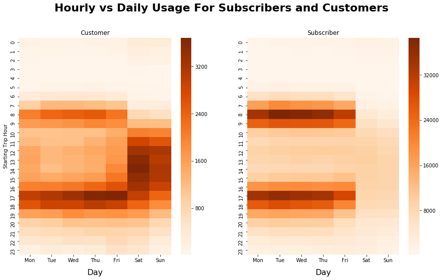

```python
df_clean['start_day'] = pd.Categorical(df_clean['start_day'], ordered=True,
                                                categories=['Mon','Tue','Wed','Thu','Fri','Sat', 'Sun'])
plt.figure(figsize=(15,8))
plt.suptitle('Hourly vs Daily Usage For Subscribers and Customers', fontsize = 22, fontweight='semibold', y = 1)

#Customers
plt.subplot(1, 2, 1)
df_customer = df_clean.query('user_type == "Customer"').groupby(["start_hour", "start_day"])["bike_id"].size().reset_index()
df_customer = df_customer.pivot("start_hour", "start_day", "bike_id")
sb.heatmap(df_customer, cmap = 'Oranges')
plt.title("Customer", y = 1.015)
plt.xlabel('Day', fontsize = 16, labelpad = 12)
plt.ylabel('Starting Trip Hour')

#Subscribers
plt.subplot(1, 2, 2)
df_subscriber = df_clean.query('user_type == "Subscriber"').groupby(["start_hour", "start_day"])["bike_id"].size().reset_index()
df_subscriber = df_subscriber.pivot("start_hour", "start_day", "bike_id")
sb.heatmap(df_subscriber, cmap="Oranges")
plt.title("Subscriber", y = 1.015)
plt.xlabel('Day', fontsize = 16, labelpad = 12)
plt.ylabel('');

plt.savefig('Figures/hourly_vs_daily_per_type.png', bbox_inches = 'tight', pad_inches = 1)
```

The plot re-suggest all what have been suggested and expected earlier about the diffrent trends for each type:

- **Subscribers:** Use bikes mainly on weekdays.
  - Weekdays: Most rides are at (8 AM - 9 AM) and (5 PM - 6 PM), and its peak is at (Tuesdays, 8 AM).
  - Weekends: There is a significant drop in the demand of bikes compared to weekdays.
- **Customers:** Use bikes more often on weekends.
  - Weekdays: Most rides are at (8 AM - 9 AM) and (5 PM - 6 PM), and its peak is at (Friday, 5 PM).
  - Weekends: Most rides are at (10 AM - 7 PM), and its peak is at (Saturday, 2 PM).

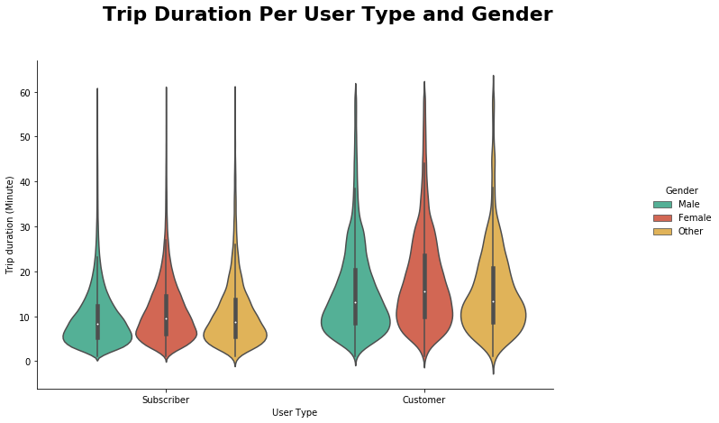

```python
fig = sb.catplot(data=data2, y='duration_min', x="user_type", hue="member_gender",
               kind="violin",  palette = [colors[2], colors[0], colors[1]])

fig.set_axis_labels("User Type", "Trip duration (Minute)")
fig._legend.set_title('Gender')
fig.fig.suptitle('Trip Duration Per User Type and Gender', y=1.1, fontsize=22, fontweight='semibold');
plt.gcf().set_size_inches(12,6)

plt.savefig('Figures/trip_duration_per_type_and_gender.png', bbox_inches = 'tight', pad_inches = 1)
```

The plot suggest that no matter what is the user type, females always spend more time in their trips compared to others. However, the differnce is small and not significant for subscribers.

### Were there any interesting or surprising interactions between features?

There is a significant drop in subscribers demand at weekends, it is very significant. Also, I observe that females spend more time in their trips compared to others.